# IHE Delft

## Assigment module Transient Groundwater Flow

## Feb 2023

Prof. dr.ir. T.N.Olsthoorn

Teacher

16 March 2023

```python
import numpy as np
import matplotlib.pyplot as plt
import os
from scipy.special import exp1

participant = 4
```

Using the data for participant 4

19 Feb 2023, 15 March 2023

```python
!pwd
```

```
/Users/Theo/Entiteiten/IHE/IHE2022-2023/Assignment/AssignmentTransient2023
```

# Introduction

Consider a water-table aquifer with fixed $kD$ and specific yield $S$ in a land, 3 km wide, bounded by straight rivers and or impervious rock boundaries as shown in the pictures in the accompanying PowerPoint file. The thickness of the aquifer is $D=30$ m and can be considered constant. A new pumping station for drinking water production is installed consiting of the wells as indicated in the picture, each extracting 600 m<sup>3</sup>/d from $t=0$.

The transmissivity $kD$ and storage coefficient $S$ (i.e. specific yield) are to be determined from a pumping test of which data measurements are given in the accompanying Excel file.

Notice that each participant has a somewhat different situation and different pumping test data. The pumping tests have been one with one of the final wells at an extraction rate of 900 m<sup>3</sup>/d.

[figure not shown]

# Questions

1. Select your situation and data from the PowerPoint and Excel files. The pictures and data sets for each participant are indicated by participant number which are associated with participant names in the Excel file.
2. Determine the transmissivity and the storage coefficient (specific yield) from the pumping test. Each test was done using 3 obsevation wells at distances 10, 20 and 30 m as indicated in the Excel file. The times are given in days and the drawdowns in m.
3. Use the obtained $kD$ and $S$ for the questions below, which refer to the entire well field.
4. Consider that the river stage (=its water level) along line C-D will fluctuate according to the $sine$ function by 2.5 m up and 2.5 m down during the year. Compute the maximum and minimum total inflow from the river due to this fluctuation. (If there is a river perpendicular to C-D, ignore it for this question).
5. What is the half-time for the natural drainage of this strip of land?
6. The further questions refer to the entire well field (ignoring fluctuations of the river stage).
7. Make a graph of the drawdown on along the line A-B to the wells for times t=30,300,3000,30000 days.
8. Compute and show the inflow along the river, line C-D, at t=300 days.
9. Compute the total flow from this river at $t=300$ days.
10. Compute and show the groundwater flow pattern at $t=300$ days.

# Accompanying files

FigsAssignment2023.pptx -- The figure for participant 4 is shown above.

DataAssignment2023.xlsx -- Data for participant 4 was copied to a .txt file and is shown below:

The data for particpant was copied from the mentioned Excel file to the text file 'DataPartic4.txt'. It loaded using np.loadtext and shown below.

The columns are:

[time[d], s(r=10m), s(r=20m), s(r=30m)]

```python
data = np.loadtxt('DataPartic4.txt')
data
```

```
array([[ 0.01 ,  0.   ,  0.03 ,  0.   ],
       [ 0.013,  0.05 ,  0.   ,  0.01 ],
       [ 0.016,  0.05 , -0.03 , -0.01 ],
       [ 0.02 ,  0.08 , -0.01 ,  0.01 ],
       [ 0.025,  0.11 ,  0.01 , -0.04 ],
       [ 0.032,  0.12 , -0.01 ,  0.   ],
       [ 0.04 ,  0.12 ,  0.02 , -0.03 ],
       [ 0.05 ,  0.2  ,  0.02 ,  0.06 ],
       [ 0.063,  0.2  ,  0.07 ,  0.01 ],
       [ 0.079,  0.26 ,  0.09 ,  0.05 ],
       [ 0.1  ,  0.27 ,  0.11 ,  0.04 ],
       [ 0.126,  0.37 ,  0.11 ,  0.02 ],
       [ 0.158,  0.33 ,  0.14 ,  0.11 ],
       [ 0.2  ,  0.41 ,  0.15 ,  0.1  ],
       [ 0.251,  0.48 ,  0.22 ,  0.11 ],
       [ 0.316,  0.49 ,  0.21 ,  0.14 ],
       [ 0.398,  0.58 ,  0.28 ,  0.14 ],
       [ 0.501,  0.62 ,  0.36 ,  0.2  ],
       [ 0.631,  0.6  ,  0.41 ,  0.21 ],
       [ 0.794,  0.71 ,  0.42 ,  0.33 ],
       [ 1.   ,  0.69 ,  0.42 ,  0.29 ],
       [ 1.259,  0.75 ,  0.52 ,  0.37 ],
       [ 1.585,  0.77 ,  0.54 ,  0.33 ],
       [ 1.995,  0.84 ,  0.57 ,  0.44 ],
       [ 2.512,  0.86 ,  0.62 ,  0.44 ],
       [ 3.162,  0.91 ,  0.67 ,  0.52 ],
       [ 3.981,  0.96 ,  0.69 ,  0.56 ],
       [ 5.012,  1.01 ,  0.77 ,  0.62 ],
       [ 6.31 ,  1.06 ,  0.79 ,  0.66 ],
       [ 7.943,  1.12 ,  0.84 ,  0.68 ],
       [10.   ,  1.15 ,  0.85 ,  0.73 ]])
```

# To reduce the amount of work, drop the parallel boundary not being the line CD

This reduces the mirroring to only once instead of an infinite number. Including a larger number of mirror wells is readily possible, but just more work to set up the scheme. Drop it for this assignment.

## Start with the pumping test (Answers to questions 1, 2, and 3)

1. First select your data from the excel file.
2. Copy it in a text file.
3. Read into an array to work with
4. Start working that.

### Reading and showing the data:

[figure not shown]

```python
data = np.loadtxt('DataPartic4.txt')

t = data[:, 0] # [d]

plt.plot(t, data[:, 1], 'b' , label='r = 10 m')
plt.plot(t, data[:, 1], 'r.', label='r = 10 m')
plt.plot(t, data[:, 2], '.' , label='r = 20 m')
plt.plot(t, data[:, 3], '.' , label='r = 30 m')

plt.title("pumping test of assignment, participant {particpant}")
plt.ylabel('drawdown [m]')
plt.xlabel('time [d]')
plt.grid()
plt.legend(loc='lower right')
plt.xscale('log')
plt.ylim(1.0, 0.)
plt.show()
```

For convenience we choose a new variable $t$ to refer to the first column (i.e. data[:, 0]), which is time.

We also use a new veriabel $rs$ (think of it as a plural of $r$) to hold the distances of the three observation wells, whose data are in columns [1,2 3] (Note that python starts counting at zero!).

When we plot the drawdown versus $t/r^2$ instead of versus $t$, the data of the diferent piezometers should all collapes to the same line. This is becase the drawdown depends on $u$ or rather $1/u$ which is $t/r^2\times(4kD/S)$.

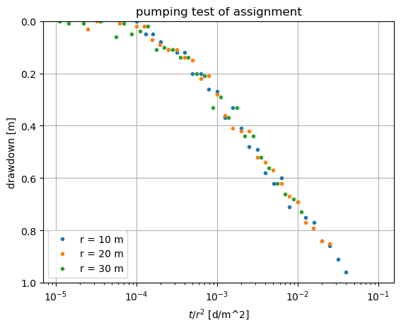

```python
t = data[:, 0] # [d], t refers to the time column.
rs = [10, 20 , 30] # distance to the three observation wells

# We can now loop over the three r's and columns, and plot versus t/r^2:
# We use range(1, 4) because the first piezometer is data[:, 1] not data[:, 0] !
# Otherwise we would have used for col, r in enumerate(rs): But than col starts with 0 instead of 1
for col, r in zip(range(1, 4), rs):
    plt.plot(t/r ** 2, data[:, col], '.', label='r = {:.0f} m'.format(r))

# Plot the drawdowns as a function of t/r2
plt.title("pumping test of assignment")
plt.ylabel('drawdown [m]')
plt.xlabel('$t/r^2$ [d/m^2]')
plt.grid()
plt.legend(loc='lower left')
plt.xscale('log')
plt.ylim(1.0, 0.)
plt.show()
```

### Determining the transmissivity and the storage coefficient

The lines indeed fall on a single line, except for some noise in the data, which is normal. From the straight portion of the line, using the simplified Theis formula

$$s(r,t)\approx \frac {2.3\,Q} {4 \pi kD} \log_{10}\left(\frac{2.25 kD t}{r^2 S}\right)$$

we can easily get the transmissivity and the storage coefficient.

The transmissivity follows from the drawdown per logcycle of the straight part of the line, which yields

$$ s_{10t} - s_t = \frac{2.3 Q}{4 \pi kD} $$

Therefore

$$ kD = \frac{2.3 Q}{4 \pi (s_{10t} - s_t)} $$

You can no simply read the drawdown per log cycle from the drawdown graph below.

To fit a straight line through the data mathematically is, of course, not necessary. But we can do it. The formula for the straight line as a function of $\tau = t/r^2$ would be

$$ s = a + b \,\,\log_{10}(\tau)$$

We just have to fit the line by choosing the parameters $a$ and $b$ iterativaly. We can choose any cycle line for $tau$, for instancd $\tau=10^{-2}$ so that $log_{10}(\tau) = -2$, for which $s\approx0.7$. And then chose the $\tau$ for this $s=0$, which yields $\tau\approx 2\times10^{-4}. Thise two values yield

$$0.7 = a -2 b$$$$0 = a -b \log_{10}\left(2\times 10^{-4}\right) = a - 3.7\,b$$

Hence

$$ b=0.41, a=1.52$$

These two values can be used to draw the straight line

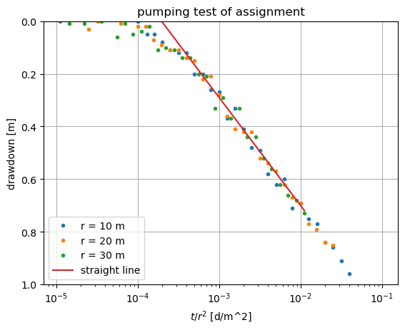

```python
a, b = 1.52, 0.41

for col, r in zip(range(1, 4), rs):
    plt.plot(t/r ** 2, data[:, col], '.', label='r = {:.0f} m'.format(r))

plt.plot(t/r ** 2, a + b * np.log10(t/r ** 2), label='straight line')


plt.title("pumping test of assignment")
plt.ylabel('drawdown [m]')
plt.xlabel('$t/r^2$ [d/m^2]')
plt.grid()
plt.legend(loc='lower left')
plt.xscale('log')
plt.ylim(1.0, 0.)
plt.show()
```

The straight line, indeed falls on the data. Otherwise we would have adjusted the a and b a bit more until we'd be satisfied with the match. And so, the drawdown per log-cycle is $b=0.41$ and the time at which the straight line hits $s=0$ is about $\tau_{s=0} \approx 2\times10^{-4}$

```python
dd_per_log_cycle = 0.41 #  s10t - s1
Q = 900 # m3/d
kD = 2.3 * Q / (4 * np.pi * dd_per_log_cycle)
print("transmissivity kD = {:.0f} m2/d".format(kD))
```

```
transmissivity kD = 402 m2/d
```

Strorage coefficient we get from $\tau = t/r^2$ where the drawdown is zero.

$$ \frac{2.25\, kD\, t_0}{r^2 S} = 1 $$

$$\tau = \frac{t_0}{r^2} = \frac{S}{2.25 kD} \approx 2 \times 10^{-4} $$

and so

```python
S = 2e-4 * 2.25 * kD
print("The storage coefficient is S = {:.2f}".format(S))
```

```
The storage coefficient is S = 0.18
```

This solves the problem.

We can easily verify the results by plotting the Theis drawdown over the data

$$ s = \frac Q {4 \pi kD} \mathrm{exp1}(u);\,\,\,\frac 1 u = \frac t {r^2} \frac{4kD}{S} $$

note that $\frac t {r^2} = \frac 1 u \frac S {4 kD}$

### Prove that the obtained parameters are correct

The graph is included in the figure below.

Then we can show that the full Theis solution fits through the data.

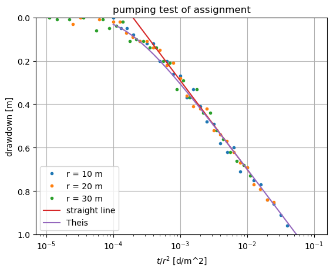

```python
a, b = 1.52, 0.41

for col, r in zip(range(1, 4), rs):
    plt.plot(t/r ** 2, data[:, col], '.', label='r = {:.0f} m'.format(r))

plt.plot(t/r ** 2, a + b * np.log10(t/r ** 2), label='straight line')

u = rs[0] ** 2 * S / (4 * kD * t)
tau = 1/u * S / (4 * kD)

plt.plot(tau, Q / (4 * np.pi * kD) * exp1(u), label='Theis')


plt.title("pumping test of assignment")
plt.ylabel('drawdown [m]')
plt.xlabel('$t/r^2$ [d/m^2]')
plt.grid()
plt.legend(loc='lower left')
plt.xscale('log')
plt.ylim(1.0, 0.)
plt.show()
```

## The river (Question 4)

Consider that the river stage (=its water level) along line C-D will fluctuate according to the $sine$ function by 2.5 m up and 2.5 m down during the year.

[figure not shown]

#### Compute the maximum and minimum total inflow from the river due to this fluctuation. (If there is a river perpendicular to C-D, ignore it for this question).

The solution for the change fluctuation $s(x,t)$ (relative to the mean) due to a sine-type fluctuation at $x=0$ is given by:

$$ s(x, t) = A e^{- a x} \sin(\omega t - a x + \theta)$$

The discharge [m<sup>2</sup>/d] then follow from the partial derivative with respect to $x$ multiplied by $-kD$

$$ Q(x, t) = -kD \frac{\partial s}{\partial x}$$

Filling in the $s(x,t) given above yields

$$ Q(x, t) = a \, kD \, A \, e^{-a x}[\sin(\omega t - a x + \theta) + \cos(\omega t - a x + \theta)] $$

where

$$ a = \sqrt{\frac{\omega S}{2 kD}} $$$$ \omega = \frac{2 \pi}{T} $$

so that for $x=0$ we have

$$ Q(x, t) = A \, \sqrt{\frac{\omega kD S} 2} [\sin(\omega t - ax + \theta) + \cos(\omega t - ax + \theta)] $$

because $\omega T = 2 \pi$

$$ Q(x, t) = A\, \sqrt{\frac{\pi kD S} T} [\sin(\omega t - ax + \theta) + \cos(\omega t - ax + \theta)] $$

So that

$$ Q(0, t) = A\, \sqrt{\frac{\pi kD S} T} [\sin(\omega t + \theta) + \cos(\omega t + \theta)] $$

with $sin(x) + cos(x) = \sqrt(2)\,\sin\left(x + \frac \pi 4\right)$

$$ Q(0, t) = A\sqrt{2}\, \sqrt{\frac{\pi kD S} T} \sin(\omega t + \theta + \frac \pi 4) $$

And, therefore, its maximum and minimum value are

$$ Q(0, t)_{max, \, min} = \pm A \sqrt{2} \sqrt{\frac{\pi kD S} T} $$

```python
A = 2.5 # m (yearly flutuation)
T = 365.25 # [d] Cycle time, a year in days
omega = 2 * np.pi / T # radians/d
a = np.sqrt(omega * S / kD)

D = 30 # aqufier thickness
n =0.35 # aquifer porosity

Q0 = A * np.sqrt(2) * np.sqrt(np.pi * kD * S / T)

print('Q0 max, min = {:.2f}, {:.2f} m2/d   Specific discharge'
                        .format(Q0, -Q0))
print('q0 max, min = {:.2f}, {:.2f} m/d    Specific discharge   (D = {:.0f} m)'
                        .format(Q0/D, -Q0/D, D))
print('v0 max, min = {:.2f}, {:.2f} m/d    Grondwater veolocity (D = {:.0f} m, n = {:.2f})'
                        .format(Q0/D/n, -Q0/D/n, D, n))
```

```
Q0 max, min = 2.79, -2.79 m2/d   Specific discharge
q0 max, min = 0.09, -0.09 m/d    Specific discharge   (D = 30 m)
v0 max, min = 0.27, -0.27 m/d    Grondwater veolocity (D = 30 m, n = 0.35)
```

### What is the half-time for the natural drainage of this strip of land?

The strip of land has a width of 3000 m, and the properties kD and S as obtained from the pumping test.

The drainage half-time stems from the exponent part first term of the of the series solution for the drainage of a strip of land. Only the first term is important because the higher terms rapidly vanish with time. Only the exponent is relevant because only the exponent depends on time.

This exponent in the first term reads (see syllabus, chapter on symmetrical drainage):

$$ \exp \left(-\left(\frac \pi 2\right)^2\frac t T \right), \,\,\,\,T = \frac{b^2 S}{kD} $$

The halftime $T_h$ then follows from

$$ \exp\left(-\left(\frac \pi 2\right)^2\frac {t + T_h}{T}\right) = 0.5 \exp\left(-\left(\frac \pi 2\right)^2\frac t T\right) $$$$ -\left(\frac \pi 2\right)^2\frac {t + T_h}{T} = \ln(0.5) -\left(\frac \pi 2\right)^2\frac t T $$$$ -\left(\frac \pi 2\right)^2 \frac {T_h} T = \ln(0.5) $$$$ \frac {T_h} T = \frac {4 \ln 2} {\pi^2}\approx 0.28 $$$$ T_h \approx 0.28 T = 0.28 \frac{b^2 S}{kD} $$

Where $b$ is the half width of the land strip. Taking the full width $L=2b$ would given

$$ T_h \approx 0.28 T = 0.28 \frac{L^2 S}{4 kD} $$

In the current situation (participant 4, see figure), the strip has a water divide at 3000 m from the river. The distance from the river to the water divide, in fact, equals $b$. Hence the half time for natural drainage from this basin is

```python
b = 3000. # m half width of basin (river to impervious wall at x=3000 m)
T = b ** 2 * S / kD
Th = 0.28 * T

print("Half time of this basin is Th = {:.0f} d, or {:.2f} y".format(Th, Th/365.25))
```

```
Half time of this basin is Th = 1134 d, or 3.10 y
```

### The further questions refer to the entire well field (ignoring fluctuations of the river stage).

We have a river perpendicular to the long side of the land strip. To take this into account, we need to mirror the two wells across this river. Mirror wells are just wells in the computation (not in reality,of course). So we figure out their coordinates and than work on with 4 wells (2 real and 2 mirror wells.) To keep the head fixed at this river, the mirror wells must have opposite sign of the flow of their counterparts.

It's convenient to pack the well information into a standard python dictionary, which allows access to the data by name.

```python
Q = 600 # [m3/d] well extraction

wells = {'w1': {'Q': Q, 'x': 1250, 'y':  500.},
         'w2': {'Q': Q, 'x': 1500, 'y': 1000.},
         'm1': {'Q':-Q, 'x': 1250, 'y': -500.},
         'm2': {'Q':-Q, 'x': 1500, 'y':-1000.}
}
```

#### Make a graph of the drawdown on along the line A-B to the wells for times t=30, 300, 3000, 30000 days.

To construct a graph of the drawdown along A-B we need to express this line mathematically. This is best done using the coordinates of points A and B. If A and B are coordinate vectors for these points, then with $\mu$ a variable, then the coordinates along the line can be expressed as follows

$$ xy = A + \mu (B - A) $$

whre $xy = A$ for $\mu=0$ and $xy = B$ for $\mu = 1$. Varying $\mu$ between 0 and 1 then let us access all point along line A-B. We may as well pick the locations of wells 1 and 2 for points A and B and let $\mu$ vary over a wider range, because the two well are on the line A-B.

```python
W1 = np.array([wells['w1']['x'], wells['w1']['y']])[:, np.newaxis] # turn into vertical vector
W2 = np.array([wells['w2']['x'], wells['w2']['y']])[:, np.newaxis] # turn into vertical vector

print('W1 = ', W1)
print('W2 = ', W2)
print()

# lambda function to define the coordinates
line = lambda mu: W1 + mu * (W2 - W1)

mu = np.linspace(-1, 2, 101) # running variable mu
x, y = line(mu) # compute coordinates
print("Coordinates of line through A and B, W1 and W2:")
print('x = ', x)
print('y = ', y)
print()
```

```
W1 =  [[1250.]
 [ 500.]]
W2 =  [[1500.]
 [1000.]]

Coordinates of line through A and B, W1 and W2:
x =  [1000.  1007.5 1015.  1022.5 1030.  1037.5 1045.  1052.5 1060.  1067.5
 1075.  1082.5 1090.  1097.5 1105.  1112.5 1120.  1127.5 1135.  1142.5
 1150.  1157.5 1165.  1172.5 1180.  1187.5 1195.  1202.5 1210.  1217.5
 1225.  1232.5 1240.  1247.5 1255.  1262.5 1270.  1277.5 1285.  1292.5
 1300.  1307.5 1315.  1322.5 1330.  1337.5 1345.  1352.5 1360.  1367.5
 1375.  1382.5 1390.  1397.5 1405.  1412.5 1420.  1427.5 1435.  1442.5
 1450.  1457.5 1465.  1472.5 1480.  1487.5 1495.  1502.5 1510.  1517.5
 1525.  1532.5 1540.  1547.5 1555.  1562.5 1570.  1577.5 1585.  1592.5
 1600.  1607.5 1615.  1622.5 1630.  1637.5 1645.  1652.5 1660.  1667.5
 1675.  1682.5 1690.  1697.5 1705.  1712.5 1720.  1727.5 1735.  1742.5
 1750. ]
y =  [   0.   15.   30.   45.   60.   75.   90.  105.  120.  135.  150.  165.
  180.  195.  210.  225.  240.  255.  270.  285.  300.  315.  330.  345.
  360.  375.  390.  405.  420.  435.  450.  465.  480.  495.  510.  525.
  540.  555.  570.  585.  600.  615.  630.  645.  660.  675.  690.  705.
  720.  735.  750.  765.  780.  795.  810.  825.  840.  855.  870.  885.
  900.  915.  930.  945.  960.  975.  990. 1005. 1020. 1035. 1050. 1065.
 1080. 1095. 1110. 1125. 1140. 1155. 1170. 1185. 1200. 1215. 1230. 1245.
 1260. 1275. 1290. 1305. 1320. 1335. 1350. 1365. 1380. 1395. 1410. 1425.
 1440. 1455. 1470. 1485. 1500.]
```

The drawdown $s$ due to all wells along the line $x$, $y$ can now be computed and drawn.

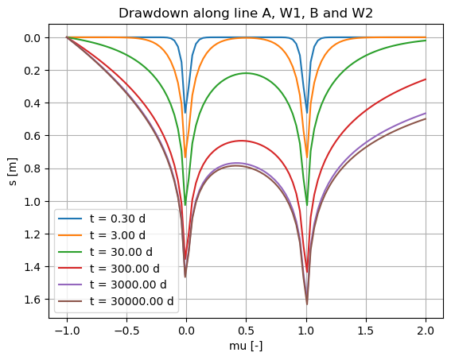

```python
ts = [0.3, 3, 30, 300, 3000, 30000] # d
rw = 0.25 # well radius

for t in ts:
    s = np.zeros_like(x) # initialize
    for k in wells: # yields the keys of the wells (you can also use wells.keys())
        well = wells[k] # well with name k
        r = np.sqrt((well['x'] - x) ** 2 + (well['y'] - y) ** 2)
        r [r < rw] = rw # make sure the smallest distance is the well radius (prevent zero)
        u = r ** 2 * S / (4 * kD * t)
        s += well['Q'] / (4 * np.pi * kD) * exp1(u) # add to
    plt.plot(mu, s, label='t = {:.2f} d'.format(t))

plt.title('Drawdown along line A, W1, B and W2')
plt.xlabel('mu [-]')
plt.ylabel('s [m]')
plt.grid()
plt.ylim(plt.gca().get_ylim()[::-1]) # turns y-axis upside down
plt.legend()
plt.show()
```

Aa can be seen, the wells are at $mu=0$ and $mu=1$. But one may just as well plot against the $x$ or the $y$ or even the distance along the line. This would not change the graph, only the coordinate on the horizontal axis.

Notice that the mirror wells are included in this graph. They ensure that the drawdow at the perpendicular river is zero. The line intersects this river at $mu = -1$.

#### Compute and show the inflow along the river, line C-D, at t=300 days.

To compute the inflow from the river along the long axis of the valley, the wells, including the mirror wells that we have so far, need to be mirrored across the other river. In fact, we have to mirror them an infinite number of times, due to the boundary on the other side of the land strip. But for now, we ignore that other boundary and mirror the wells across the river. With currently four wells, we will have 8 after this mirroring. Here they are, including the opposite sign of the extraction of their counterpart.

```python
Q = 600 # [m3/d] well extraction

wells1 = {'w1': {'Q': +Q, 'x': 1250, 'y':  500.},
          'w2': {'Q': +Q, 'x': 1500, 'y': 1000.},
          'm1': {'Q': -Q, 'x': 1250, 'y': -500.},
          'm2': {'Q': -Q, 'x': 1500, 'y':-1000.},
          # Mirror wells:
          'w1m': {'Q': -Q, 'x': -1250, 'y':  500.},
          'w2m': {'Q': -Q, 'x': -1500, 'y': 1000.},
          'm1m': {'Q': +Q, 'x': -1250, 'y': -500.},
          'm2m': {'Q': +Q, 'x': -1500, 'y':-1000.},
}

# Drawdown along line perpendicular to long axis of the land along y = 750

P1 = np.array([   0, 750])[:, np.newaxis]
P2 = np.array([3000, 750])[:, np.newaxis]
mu = np.linspace(-1, 1, 501)

line1 = lambda mu: P1 + mu * (P2 - P1)

x1, y1 = line1(mu)
#print('x1 =', x1)
#print('y1 =', y1)
```

First plot a picture of the layout of the wells, the rivers and the impervious boundary.

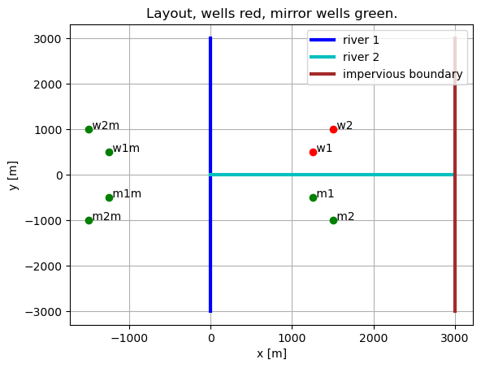

```python
plt.title("Layout, wells red, mirror wells green.")
plt.xlabel('x [m]')
plt.ylabel('y [m]')
plt.grid()

plt.plot([0,    0], [3000, -3000], 'b', lw=3, label='river 1')
plt.plot([0, 3000], [   0,     0], 'c', lw=3, label='river 2')
plt.plot([3000, 3000], [-3000, 3000], 'brown', lw=3, label='impervious boundary')

for k in wells1:
    well = wells1[k]
    ls = 'go' if k[-1] == 'm' or k[0] == 'm' else 'ro' # marker for well red for mirror green
    plt.plot(well['x'], well['y'], ls)
    plt.text(well['x'], well['y'], ' ' + k, ha='left')
plt.legend()
plt.show()
```

Then plot the dawdown along the line $y=750$ m.

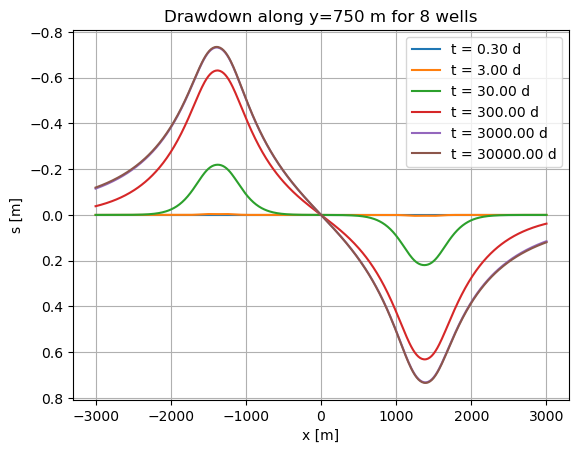

```python
plt.title("Drawdown along y={:.0f} m for {} wells".format(y1[0], len(wells1)))
plt.xlabel('x [m]')
plt.ylabel('s [m]')
plt.grid()

for t in ts:
    s = np.zeros_like(x1)
    for k in wells1:
        well = wells1[k]
        r = np.sqrt((well['x'] - x1) ** 2 + (well['y'] - y1) ** 2)
        u = r ** 2 * S / (4 * kD * t)
        s += well['Q'] / (4 * np.pi * kD) * exp1(u)
    plt.plot(x1, s, label='t = {:.2f} d'.format(t))
plt.legend()
plt.ylim(plt.gca().get_ylim()[::-1])
plt.show()
```

We can plot the dawdowns along any line, but teh best insight is obtained when plotting contour lines for the drawdown at given times. This can be combined with the layout.

A convenient way is to capsulate the plotting of the layout in a simple function.

```python
def plot_layout(wells=None):
    """Plot the layout."""
    plt.plot([0,    0], [3000, -3000], 'b', lw=3, label='river 1')
    plt.plot([0, 3000], [   0,     0], 'c', lw=3, label='river 2')
    plt.plot([3000, 3000], [-3000, 3000], 'brown', lw=3, label='impervious boundary')
    plt.xlabel('x [m]')
    plt.ylabel('y [m]')
    plt.grid()

    if wells is None:
        wells = wells1
    for k, well in wells.items():
        ls = 'go' if k[-1] == 'm' or k[0] == 'm' else 'ro' # marker for well red for mirror green
        plt.plot(well['x'], well['y'], ls)
        plt.text(well['x'], well['y'], ' ' + k, ha='left')
    plt.legend()
```

The plot the drawdown at a given time t. For this to work, we need coordinates for a regular grid of points.

```python
x2 = np.linspace(-3100, 3100, 101)
y2 = np.linspace(-3100, 3100, 101)
X, Y = np.meshgrid(x2, y2)
print("Number of gridpoints in y and x direction = ", X.shape)
```

```
Number of gridpoints in y and x direction =  (101, 101)
```

The compute the drawdown

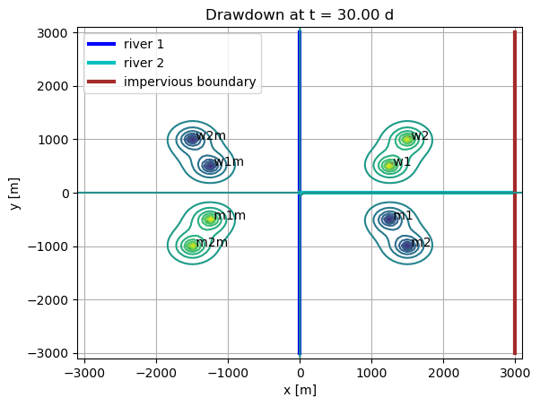

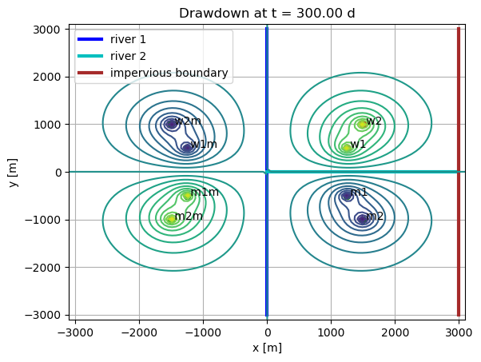

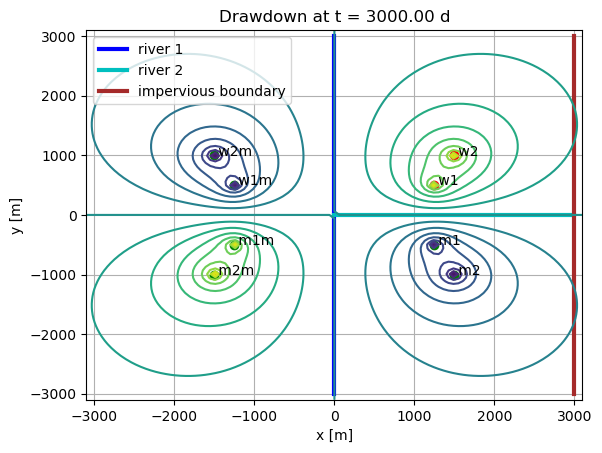

```python
for t in ts[2:-1]:
    plot_layout()
    plt.title("Drawdown at t = {:.2f} d".format(t))
    s = np.zeros_like(X)
    for k in wells1:
        well = wells1[k]
        r = np.sqrt((well['x'] - X) ** 2 + (well['y'] - Y) ** 2)
        u = r ** 2 * S / (4 * kD * t)
        s += well['Q'] / (4 * np.pi * kD) * exp1(u)
    plt.contour(X, Y, s, levels = 25)
    plt.show()
```

We just asked for 25 contour levels. However, the exact levels can be provided in a list. And the contour lines can also be labeled. You may want to look this up.

#### Compute the total flow from this river at $t=300$ days.

It's clear from the picture that the drawdowns cross the impervious boundary. This is due to the fact that we ignored having to perform an infinite number of mirroring to make sure that not only the head at the river remains zero, but also the flow across the impervious boundary.

Ignoring infinite mirroring for simplicity, we can now set uit the infiltration across the river boundary. For which we take the river along $x=0$, i.e. the y-axis.

The total discharge at radius R due to a well in the Theis case is

$$ Q(r,t) = Q_w e^{-u} $$

and, therefore

$$ q(r,t) = \frac{Q_w}{2 \pi r} e^{-u}$$

and the two components are

$$ q_x(r,t) = \frac{Q_w}{2 \pi r^2} (x_w - X) e^{-u}$$$$ q_y(r,t) = \frac{Q_w}{2 \pi r^2} (y_w - Y) e^{-u}$$

Which allows us to show a velocity (or specific discharge field) as well as to compute the discharge across a line, like, in our case, the river.

First show the inflow from the river.

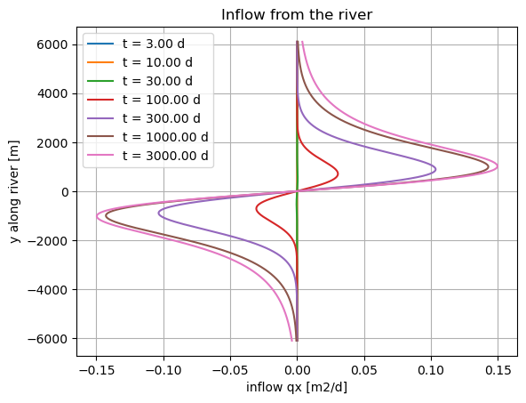

```
qy average = 7.428e-15 m2/d. Hence, effecively zero as expected.
```

```python
ts = [3, 10, 30, 100, 300, 1000, 3000]

Yr = np.linspace(-6100, 6100, 3001)
Xr = np.zeros_like(Yr)

plt.title("Inflow from the river")
plt.xlabel("inflow qx [m2/d]")
plt.ylabel('y along river [m]')
plt.grid()

for t in ts:
    qx = np.zeros_like(Yr)
    qy = np.zeros_like(Yr)
    for k in wells1:
        well = wells1[k]
        Qw, xw, yw = well['Q'], well['x'], well['y']
        r2 = (xw - Xr) ** 2 + (yw - Yr) ** 2
        u = r2 * S / (4 * kD * t)
        qx += Qw / (2 * np.pi * r2) * (xw - Xr) * np.exp(-u)
        qy += Qw / (2 * np.pi * r2) * (yw - Yr) * np.exp(-u)
    plt.plot(qx, Yr, label='t = {:.2f} d'.format(t))
plt.legend()
plt.show()
print('qy average = {:.5g} m2/d. Hence, effecively zero as expected.'.format(np.abs(qy).sum()))
```

Notice that the real world only exists for $x>=0, \, y>=0$; the rest is in the mirror world. But we can still show it as was done above.

The graphs show that only after about 30 days does the effect of the well extraction affect the inflow from the river, while after in the order of 3000 days, the inflow from the wells has become steady.

Also notice that the inflow at the intersection of the two rivers is zero as it should be; exactly at the intersection, there is no gradient possible.

The total inflow can be computed by integrating the specific inflow $q_x$ along the $y$-axis. This can be done by mulitplying the $q_x$ at points along the river by their distance and sum the values. We do this below and turn the data into a graph showing the development of the inflow over time. Clearly, we should do this only for $y>0$. Due to all the wells, integrating from $-y$ to $+y$ always yields exactly zero for any $y$ along the river.

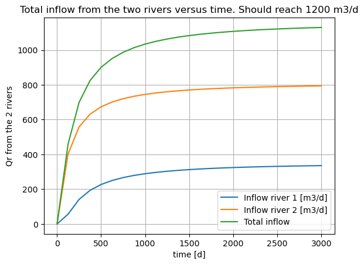

```python
ts = np.linspace(0, 3000, 25)

# First river
Yr1 = np.linspace(0, 6100, 3001) # now from y=0 upwards along the river
Xr1 = np.zeros_like(Yr1)

# Second river
Xr2 = np.linspace(0, 6100, 3001)
Yr2 = np.zeros_like(Xr2)

Qr = np.zeros((2, len(ts)))

for it, t in enumerate(ts): # All times
    for ir, (X, Y) in enumerate(zip([Xr1, Xr2], [Yr1, Yr2])): # The two rivers
        qx = np.zeros_like(Y)
        qy = np.zeros_like(Y)
        for k in wells1:
            well = wells1[k]
            Qw, xw, yw = well['Q'], well['x'], well['y']
            r2 = (xw - X) ** 2 + (yw - Y) ** 2
            u = r2 * S / (4 * kD * t)
            qx += Qw / (2 * np.pi * r2) * (xw - X) * np.exp(-u)
            qy += Qw / (2 * np.pi * r2) * (yw - Y) * np.exp(-u)

        Qr[ir][it] = np.sum(0.5 * (qx[:-1] + qx[1:]) * np.diff(Y)) +\
                     np.sum(0.5 * (qy[:-1] + qy[1:]) * np.diff(X))

Qwells = 0
for k in wells1:
    if not k[0] == 'm' or k[-1] == 'm':
        Qwells += wells1[k]['Q']

plt.title("Total inflow from the two rivers versus time. Should reach {} m3/d".format(Qwells))
plt.xlabel("time [d]")
plt.ylabel("Qr from the 2 rivers")
plt.grid()
plt.plot(ts, Qr[0], label="Inflow river 1 [m3/d]")
plt.plot(ts, Qr[1], label="Inflow river 2 [m3/d]")
plt.plot(ts, Qr[0] + Qr[1], label="Total inflow")
plt.legend()
```

#### Compute and show the groundwater flow pattern at $t=300$ days.

The groundwater flow pattern is a field showing the groundwater velocity or specific discharge at any point as a vector. It's straight forward to compute components $q_x$ and $q_y$ at every grid point. To show them, we plot a line starting at every grid point in the direction of the specific discharge vector. The lengt of the line is propertional to the size of the vector. We us a scale factor to scale these vectors such that the picture is pleasing. This tweaking of the scale factor is done by hand.

[figure not shown]

```python
ts = [300]

scalefactor = 500.

x = np.linspace(0, 3000, 31)
y = np.linspace(0, 3000, 31)
X, Y = np.meshgrid(x, y)

plot_layout()
plt.title("FLow pattern at t = {:.0f} d".format(t))

for t in ts:
    qx = np.zeros_like(X)
    qy = np.zeros_like(X)
    s  = np.zeros_like(X)
    for k in wells1:
        well = wells1[k]
        Qw, xw, yw = well['Q'], well['x'], well['y']
        r2 = (xw - X) ** 2 + (yw - Y) ** 2
        r2[r2 < rw ** 2] = rw ** 2
        u = r2 * S / (4 * kD * t)
        s  += Qw / (4 * np.pi * kD) * exp1(u)
        qx += Qw / (2 * np.pi * r2) * (xw - X) * np.exp(-u)
        qy += Qw / (2 * np.pi * r2) * (yw - Y) * np.exp(-u)
    plt.contour(X, Y, s, levels=25)
    Xv = X + qx * scalefactor
    Yv = Y + qy * scalefactor
    plt.plot([X.ravel(), Xv.ravel()], [Y.ravel(), Yv.ravel()], lw=0.5)
plt.show()
```

# Final remarks

This finishes the assignment. We skipped the mirroring of the wells to also take the impervious wall into account. It would mean another loop or putting all those mirror wells into the dictionary first and then loop over the wells. The number of mirrors has to be tried, because one cannot loop in infinite times in a computer. Ten of twenty times would normally be enough.

## Taking into t the opposite boundary

For this we have to mirror every well (including the mirror wells opposite the perpendicular river) an infinite time, or at least sufficient number of times, to break off safely.

The figure below shows the land strip of width $b$ in the center with its well somewhere in the strip and the mirror scheme.

[figure not shown]

Assuming the two barriers are parallel to the y-axis, so that their coordinates are $xL=0$ and $xR=b$, and the well in question has coordinage $x=xW$ can write the mirroring as follows as a series.

To get this scheme, one starts at the well (0) and jumps over one boundary to find the location of the first mirror well (1). Then this well jumps over the other boundary to get the location of the next well (2). This procedure is repeated as many times as deemed necessary. The results is all the mirror wells that result from first jumping over the right boundary (The blue lines and wells).

This procedure is like at tic-toc game with ever larger jumps.

Then we start at the well (0) again, and now first jump over the other boundary as indicated in read. The same procedure as outlined above is repeated over and over again. The result is all the red mirror wells.

In the end we have one well in the land strip and all the blue and red mirror wells, which, together they have to make sure the boundary conditions are met at the boundaries of the strip.

The sign of the wells, extraction or injection, depends on the type of boundary a both sides of the strip (see picture below). An impervious boundary (indicated by "rock") demands zero flow across it. Hence the mirror well on the other side of such a boundary has the same sign as the well itself. A fixe-head boundary on the other hand (indicated by "River") requires the mirror well at the opposite side of the boundary to have opposite sign. These rules are applied in the figure below. First for the blue wells (the series that started by jumping first over the right-hand (impervious) boundary), then for the red wells (the series that started by jumpoing first over the left (fixed head) boundary.)

[figure not shown]

Then, when the scheme of mirror wells has become clear, we can check if it is indeed correct, i.e. if it does indeed ensure the boundary conditions are met at both sides of the strip.

That this is indeed the case, can easily be seen from the scheme. It's obvious from the scheme that the blue wells to the right and left of the right-hand boundary (between the blue wells 0 and 1) all cancel out, and also, that the same is true for the red wells. Hence, there is zero flow across the right-hand boundary of the yellow strip.

When we look at the left-hand boundary of the strip it is immediately clear that the head change at this boundary due to any pair of blue wells cancels out, so that it remains zero. The same is true for the red wells. Hence there can be no head change at the left well due to the extraction well in the strip, and also no flow across the right-hand boundary of the strip due to the well in the strip.

The correctness of the scheme might be even seen more easily when the two series of mirror wells are merged as in the figure below.

[figure not shown]

To implement such a scheme, we write a function that first computes the blue mirror wells and then the red ones. This is convenient as the next well location follows from the previous one and the boundary to jump. Also the sign of the well flow will alternate with every step, except the first one in the case of a rock boundary.

```
well and mirror wells
[(600.,   2000., 0.,  1) (600.,   4000., 0.,  1) (600.,  -4000., 0., -1)
 (600.,  10000., 0., -1) (600., -10000., 0.,  1) (600.,  16000., 0.,  1)
 (600., -16000., 0., -1) (600.,  22000., 0., -1) (600., -22000., 0.,  1)
 (600.,  28000., 0.,  1) (600., -28000., 0., -1) (600.,  34000., 0., -1)
 (600., -34000., 0.,  1) (600.,  40000., 0.,  1) (600., -40000., 0., -1)
 (600.,  46000., 0., -1) (600., -46000., 0.,  1) (600.,  52000., 0.,  1)
 (600., -52000., 0., -1) (600.,  58000., 0., -1) (600.,  -2000., 0., -1)
 (600.,   8000., 0., -1) (600.,  -8000., 0.,  1) (600.,  14000., 0.,  1)
 (600., -14000., 0., -1) (600.,  20000., 0., -1) (600., -20000., 0.,  1)
 (600.,  26000., 0.,  1) (600., -26000., 0., -1) (600.,  32000., 0., -1)
 (600., -32000., 0.,  1) (600.,  38000., 0.,  1) (600., -38000., 0., -1)
 (600.,  44000., 0., -1) (600., -44000., 0.,  1) (600.,  50000., 0.,  1)
 (600., -50000., 0., -1) (600.,  56000., 0., -1) (600., -56000., 0.,  1)]
```

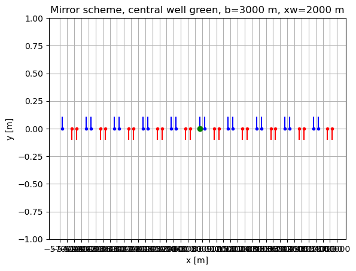

```python
def get_mirror_wells(Q=600., xw=2000, yw=0., b=3000., leftfixed=True, rightfixed=False, N=20):
    """Return rec array with the well and its mirror wells.

    dtype = [Q, x, y, sign]

    Blue wells first jump over the right boundary; the read ones first jump over the left boundary.

    Parameters
    ----------
    Q: float
        well discharge
    xw: float
        well coordinate
    b: float
        width of the land strip
    leftfixed: bool
        True if left boundary is fixed head; False if it is zero flow.
    rightfixed: bool
        True if right boundary is fixed head; False if it is zero flow.

    Returns
        Recarray with the well coordinates and sign of discharge.
        dtype = np.dtype([('Q', float), ('x', float), ('y', float), ('sign', int)])
        The first in the recarray is the well itself, the others are the mirror wells.
    """

    dtype = np.dtype([('Q', float), ('x', float), ('y', float), ('sign', int)])
    bluewells = np.zeros(N, dtype=dtype) # First jump is over the right boundary
    redwells  = np.zeros(N, dtype=dtype) # First jump is over the left boundary

    xB = [0.,  b]  # May change this into arbitrary xL and xR coordinates
    tp = [-1. if leftfixed   else +1,  # sign of first well
          -1. if rightfixed  else +1.]

    bluewells[0] = np.array((Q, xw, yw, 1), dtype=dtype)
    redwells[ 0] = np.array((Q, xw, yw, 1), dtype=dtype)

    for i in range(1, N):
        ib = (i + 0) % 2 # jump right if 1 else left
        ir = (i + 1) % 2 # jump left if 1 else right

        bluewells[i] = np.array((Q, 2 * xB[ib] -bluewells[i - 1]['x'], yw, bluewells[i-1]['sign'] * tp[ib]), dtype=dtype)
        redwells[ i] = np.array((Q, 2 * xB[ir] -redwells[ i - 1]['x'], yw, redwells[i-1]['sign'] * tp[ir]), dtype=dtype)
    wells = np.concatenate((bluewells, redwells[1:]), axis=0)
    return wells

# Example
Q, b, xw, N = 600., 3000., 2000., 20
wells = get_mirror_wells(Q=Q, xw=xw, b=b, leftfixed=True, rightfixed=False, N=N)

# Plot it
print('well and mirror wells')
print(wells)

plt.title('Mirror scheme, central well green, b={:.0f} m, xw={:.0f} m'.format(b, xw))
plt.xlabel('x [m]')
plt.ylabel('y [m]')
plt.grid()

dy = 0.1
for i, well in enumerate(wells):
    x, y, sgn = well['x'], well['y'], well['sign']
    clr = 'b' if sgn  == 1 else 'r'
    plt.plot(x, y, clr + '.')
    plt.plot([x, x], [y, y + dy * sgn], clr )
plt.plot(wells[0]['x'], wells[0]['y'], 'go')
plt.xticks(np.linspace(-19 * b, 20 * b, 40))
plt.ylim(-1., 1.)
plt.show()
```

Below we compute the drawdown due to all wells and mirror wells and show the resulting drawdown.

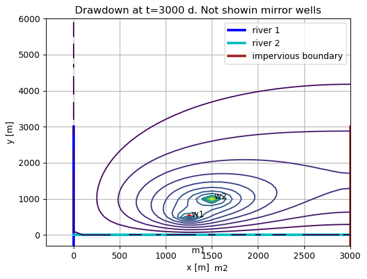

```python
t, b, Q = 3000., 3000., 600.
fpkd = 4 * np.pi * kD

# Coordinates of the grid
x = np.linspace(0, b,     31)
y = np.linspace(0, 2 * b, 61)
X, Y = np.meshgrid(x, y)

# Use only the first wells w1, w2, m1, m2
wells2 = {k: wells1[k] for k in wells1 if not k[-1]=='m'}

# Initialize
s = np.zeros_like(X)

# Loop over the wells
for k, well in wells1.items():
    # For each well compute all its mirror wells
    wells = get_mirror_wells(Q=well['Q'], xw=well['x'], yw=well['y'], b=b, leftfixed=True, rightfixed=False, N=20)

    # Loop over the well and all its mirror wells
    for w in wells:
        xw, yw, Qw = w['x'], w['y'], w['Q'] * w['sign']
        r2 = (X - xw) ** 2 + (Y - yw) ** 2; r2[r2 < rw ** 2] = rw ** 2
        u = r2 * S / (4 * kD * t)
        s += Qw / fpkd * exp1(u)

# Plot the result
plt.title("Drawdown at t={:.0f} d. Not showin mirror wells".format(t))
plot_layout(wells=wells2) # only wells 'w1', 'w2', 'm1' and 'm2'
plt.contour(X, Y, s, levels=25)
plt.xlim(-0.1 * b, b)     # set figure limits
plt.ylim(-0.1 * b, 2 * b) # set figure limits
plt.show() # finish figure
```

It is now clearly seen that the head is fixed at both rivers and that there is zero flow across the impervious rock at $x=3000$ m (i.e. the head lines are perpendicular to this boundary). The fixed head along the river at y=0 was obtained by morring 'w1' and 'w2' across this river and use opposite sign for their discharge. The fixed head at $x=0$ and the zero flow at $x=3000$ were obtained by infinitely (in practice 20 times) mirroring these latter for wells across the boundaries $x=0$ and $x=3000$ m while using the correct sign for each mirror well.

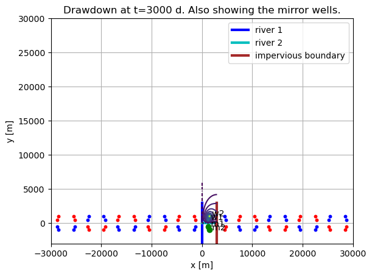

```python
s = np.zeros_like(X)
for k, well in wells1.items():
    wells = get_mirror_wells(Q=well['Q'], xw=well['x'], yw=well['y'], b=b, leftfixed=True, rightfixed=False, N=20)
    for w in wells:
        xw, yw, Qw = w['x'], w['y'], w['Q'] * w['sign']
        r2 = (X - xw) ** 2 + (Y - yw) ** 2; r2[r2 < rw ** 2] = rw ** 2
        u = r2 * S / (4 * kD * t)
        s += Qw / fpkd * exp1(u)
        plt.plot(xw, yw, 'b.' if Qw > 0 else 'r.')

plt.title("Drawdown at t={:.0f} d. Also showing the mirror wells.".format(t))
plot_layout(wells=wells2)
plt.contour(X, Y, s, levels=25)
plt.xlim(-10 * b, 10 * b)
plt.ylim(-b, 10 * b)
plt.show()
```

This concludes the assignment